# Trump’s Framing of Immigration on Twitter

Text Analysis of Donald Trump’s 2019 Tweets · November 3, 2026

Author

Stephanie Pacheco · POLS 4130 · Fall 2026

## Research Question

How does Trump use rhetorical strategies to frame immigration in his 2019 tweets?

### Data

- **Source:** Donald Trump’s tweets from January-December 2019
- **Original Corpus:** 4,469 posts
- **Analytic Sample:** 441 immigration-related tweets identified through keyword filtering
- **Unit of Analysis:** Individual tweets
- **Methods:** Word cloud, dictionary sentiment analysis, and Latent Dirichlet Allocation (LDA)

### Methods

**Word Frequency:** Tweets were tokenized, lemmatized, and cleaned of common stopwords. Frequent terms were examined to identify prominent language.

**Sentiment Analysis:** The Bing Liu sentiment dictionary assigned +1 to positive words and −1 to negative words. Word scores were summed within each tweet and averaged across tweets.

**Negation Adjustment and Coverage:** Sentiment scores were reversed when a negation term appeared within the current or previous three words. Coverage measured the proportion of tweet tokens matched to the dictionary. Mean tweet-level coverage was 88.6%.

**Target-window Sentiment:** Sentiment was measured within four words before and after immigration-related target terms and compared with whole-tweet sentiment for the same tweets.

**Topics:** Words were lemmatized and stopwords removed before fitting a three-topic Latent Dirichlet Allocation (LDA) model. Topic labels were developed by examining top words and representative original tweets.

## Frequency

After filtering for immigration-related keywords, “border” was the most frequently occurring term, followed by “wall” and “democrats,” suggesting that Trump’s immigration-related discourse frequently emphasized border-related issues and political opposition.

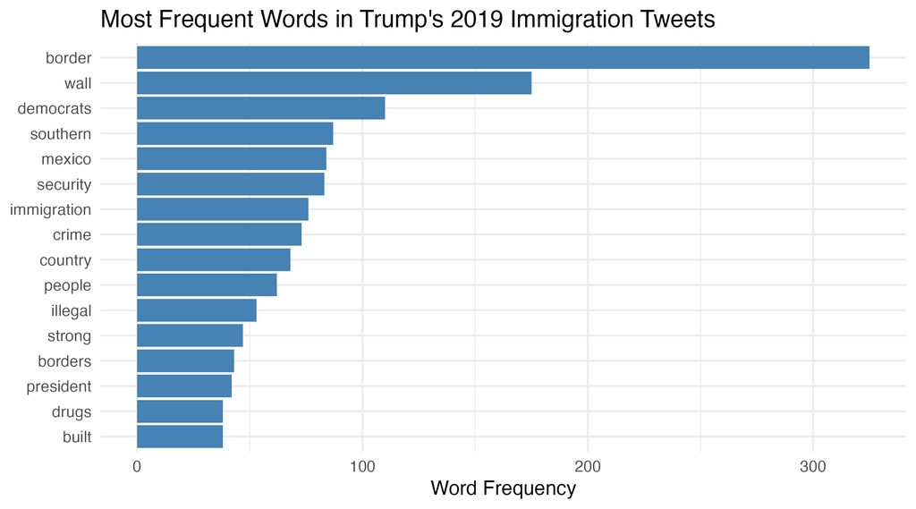

*Figure 1. Frequency Bar Chart.*

[figure not shown]

*Figure 2. Word Cloud*

## Sentiment Findings

**Overall Sentiment:** Overall sentiment was slightly negative, with the mean score decreasing from -0.014 to -0.036 after negation adjustment. This suggests that accounting for negation made the measured sentiment more negative.

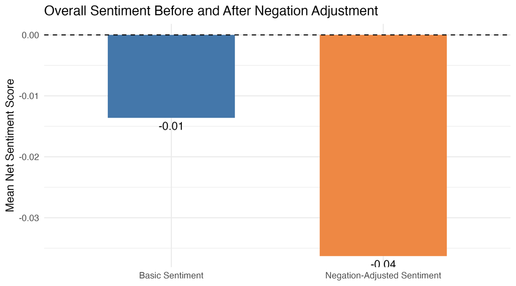

*Figure 3. Mean dictionary sentiment scores before and after negation adjustment across the immigration-related tweet sample.*

**Immigration-related Wording:** Sentiment surrounding immigration-related terms was considerably more negative at -0.225 than sentiment across the full tweets at -0.002. This suggests that language immediately surrounding immigration-related terms had a more negative tone than the broader tweet text.

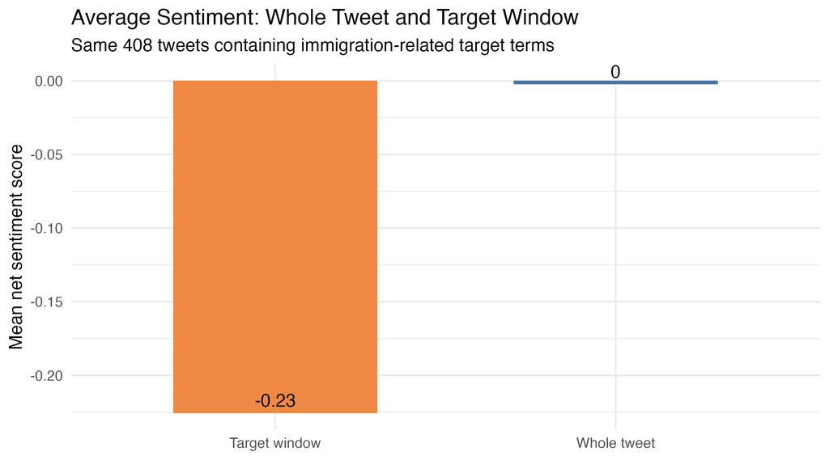

*Figure 4. Target-window and whole-tweet sentiment for tweets containing the selected immigration-related terms.*

**Sentiment by Month:** After adjusting for negation in the immigration-related filtered corpus, sentiment varied by month, with negative sentiment mainly in the beginning of the year and positive sentiment later.

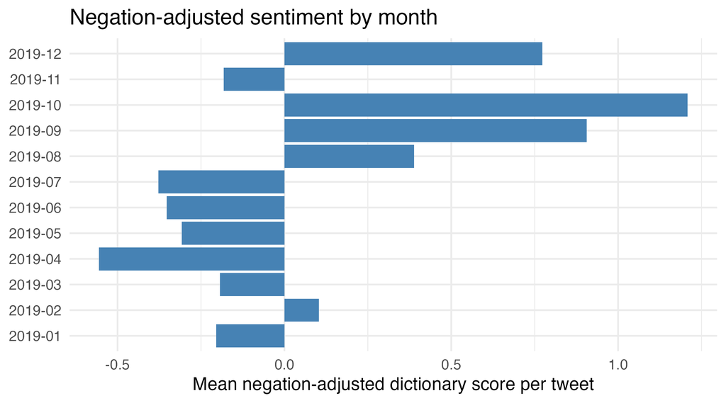

*Figure 5. Negation-adjusted Sentiment by Month.*

## Topic Modeling

**Top Words for Each Topic:** A three-topic LDA model was selected because it produced the most differentiated thematic groups. The three topics chosen were Wall Construction and Border Security, Border Politics and Crime, and Mexico and Illegality, respectively.

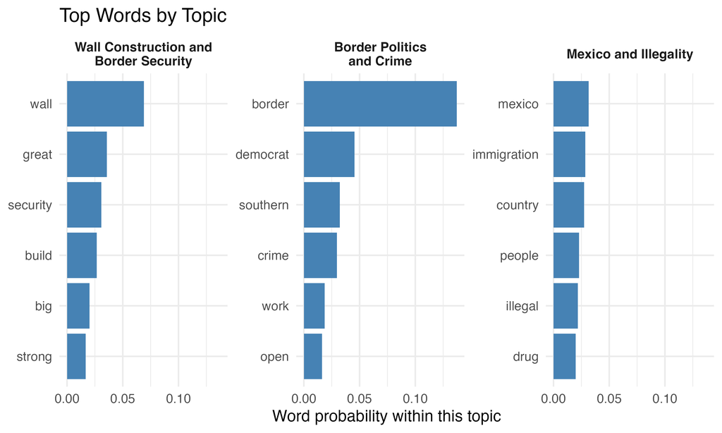

*Figure 6. Most prominent terms associated with each of the three LDA identified topics.*

**Topic Proportions:** All topics had nearly identical average proportions, each accounting for approximately 1/3 of the modeled documents. No single topic substantially dominated the overall distribution.

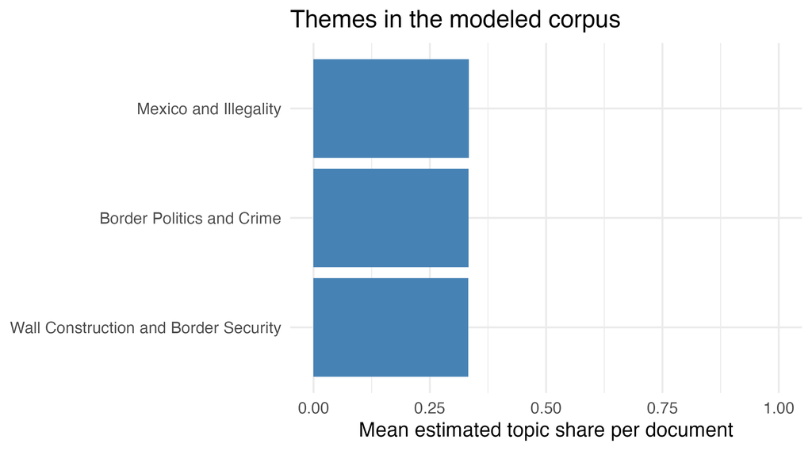

*Figure 7. Average estimated topic proportions across the documents retained for LDA topic modeling.*

**Sentiment by Topic:** Sentiment varied across the three topics. Wall Construction and Border Security had a positive average sentiment (+0.647), while Border Politics and Crime (-0.581) and Mexico and Illegality (-0.381) also had negative averages. These differences suggest that the language associated with each thematic grouping carried distinct sentiment patterns. Positive terms like ‘great’ and ‘strong’ related to the wall and security may have contributed to the positive score even when the broader message was negative.

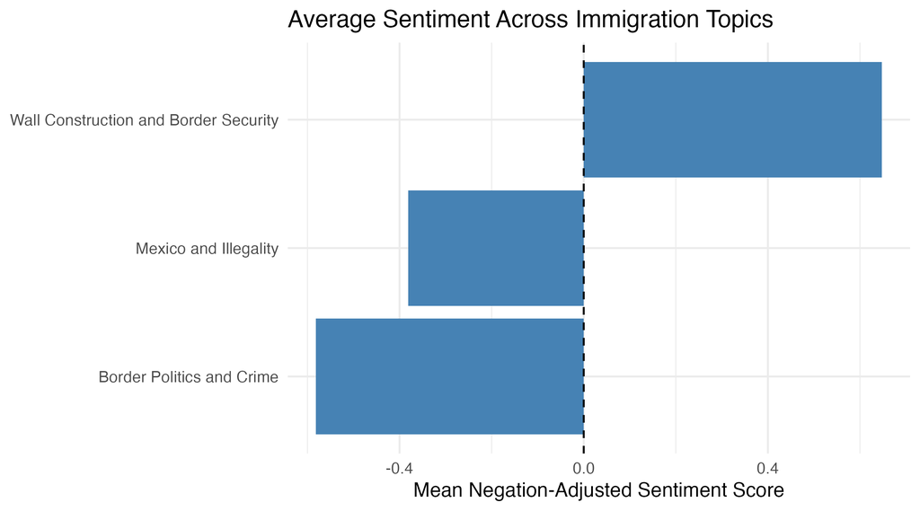

*Figure 8. Average estimated sentiment across the three identified immigration topics.*

## Examining Original Tweets

**ID: 96 | Topic 1: Wall Construction and Border Security | Sentiment Score: -2** | Tweet Excerpt: “Democrats […] are not going to give money to build the DESPERATELY needed WALL.”

**ID: 54 | Topic 2: Border Politics and Crime | Sentiment Score: -3** | Tweet Excerpt: “The Radical Democrats are a Party of open borders and crime.”

**ID: 151 | Topic 3: Mexico and Illegality | Sentiment Score: -2** | Tweet Excerpt: “Mexico is doing NOTHING to help stop the flow of illegal immigrants to our Country.”

**ID: 154 | Topic 3: Mexico and Illegality | Sentiment Score: 0** | Tweet Excerpt: “Mexico has for many years made a fortune off of the U.S., far greater than Border Costs.”

**Sentiment:** Individual tweet scores illustrate how dictionary-based sentiment can be useful in capturing some of the language used. For example, Tweet 151 states, “Mexico is doing NOTHING to help stop the flow of illegal immigrants to our Country.” Its negative wording reflects the tweet’s critical framing of immigration and Mexico, and received a negative sentiment score of -2.

**Topics:** The representative tweets illustrate the themes identified through topic modeling. Tweet 96 (Topic 1) emphasizes wall construction and border security through terms such as “WALL” and “DESPERATELY needed.” Tweet 54 (Topic 2) connects Democrats, open borders, and crime. Tweets 151 and 154 (Topic 3) focus on Mexico’s role in migration, illegal immigration, and the southern border. Together, these examples support the interpretation of the three identified topic labels.

### Limitations

**Sentiment:** Dictionary-based sentiment analysis cannot fully account for sarcasm, political context, or how words can change meaning depending on specific usage. For example, Tweet 154 criticizes Mexico for its role in migration and threatens to close the southern border, yet received a neutral sentiment score of 0. This reveals how a dictionary may not fully capture the intensity or context of political statements.

**Topics:** Topic modeling identifies patterns of word co-occurrence rather than definitive themes. However, some tweets contain multiple themes. For example, Tweet 96 discusses both wall construction and criticism of Democrats, while Tweet 154 combines Mexico’s role in migration with economic pressure and the possibility of closing the southern border. This overlap demonstrates that tweets can address multiple related themes.

### Answer to the Research Question

Trump’s 2019 immigration-related tweets used rhetorical strategies, such as word repetition, to emphasize border security, political opposition, and concerns about illegal immigration. Word frequency analysis highlighted the prominence of “border,” “wall,” and “democrats,” while topic modeling identified three recurring themes: Wall Construction and Border Security, Border Politics and Crime, and Mexico and Illegality.

Sentiment analysis revealed that language surrounding immigration-related terms was considerably more negative (-0.225) than sentiment across entire tweets (-0.002).

Together, these findings suggest that Trump’s immigration discourse frequently framed immigration through security concerns, political conflict, and illegality. Upon further inspection, the results primarily revealed negative sentiment in tweets related to immigration.

**Sources:** Trump 2019 Twitter Archive *Sentiment Dictionary:* Liu, B. (2012). Sentiment Analysis and Opinion Mining. Morgan & Claypool Publishers. data/bing_liu_dictionary.csv